# Modeling Dynamic World probabilities as timeseries of compositional data vectors

2023-10-11

# 1 Overview

## 1.1 Context

A pixel in a Dynamic World (DW) image captures probabilities 9 land cover categories. These probabilities at every pixel change as its land cover cycles through seasons each year. Modeling patterns in a timeseries of these probabilities can prove powerful in inferring more complex land cover types than are available in DW.

Using probability values of a single cover type (say, `grass`) for such timeseries modeling (to infer, say, different types of grasslands) is one way to approach this. But doing so ignores the neat mathematical structure offered by the fact that it is one component of a vector of probabilities, which change together while also summing to 1 at every time point, i.e., the probability vectors have the structure of compositional data vectors, and DW offers a timeseries of those at each pixel.

In our land cover mapping exercise identifying different types of open-canopy natural ecosystems in semi-arid India (roughly 2.5M sq. km.), **we wish to explore the compositional approach to modeling vegetation phenology using multiple linear regression on the DW timeseries** (along the lines of Nick Clinton’s tutorial on harmonic modeling in the [Time Series Analysis in Earth Engine](https://www.youtube.com/watch?v=xQGNAYL7z80) tutorial). This would involve the following steps, which is achievable using the [`{compositions}`](http://www.stat.boogaart.de/compositions/) package in R:

- apply isometric logratio (ilr) transformation to each probability vector in a timeseries
- model landcover phenology by performing harmonic analysis, using multiple linear regression, on the ilr-transformed vectors.

We have attempted this below for one pixel at a time. To be able to visualize results and build our understanding, we have reduced the numerical complexity down to a 3 probabilities case, from the 9 probabilities offered by DW.

## 1.2 How Earth Engine could help

We would like to perform this harmonic modeling on the DW dataset treated as a timeseries of compositional vector data of 9-long probability vectors. Using the results of this harmonic modeling (the coefficients, goodness of fit), we would like to build a classifier using one of the classifiers already available on Earth Engine to produce a map.

Specifically, **can there be a reducer which can perform multiple linear regression on the (ilr-transformed) compositional vectors as response variables**, returning model coefficients and goodness of fit measures?

# 2 Additional resources

- An overview of the math behind linear regression of compositional data, isometric logratio: Wang et al. (2013), “Multiple linear regression modeling for compositional data”, Neurocomputing, Volume 122, 25 December 2013, Pages 490-500. [(SciHub link)](https://sci-hub.se/10.1016/j.neucom.2013.05.025).
- Built on the [`{compositions}`](http://www.stat.boogaart.de/compositions/) package which is described by the authors in this [paper](https://sci-hub.se/10.1016/j.cageo.2006.11.017).
  - A handy primer on how to use this for linear modeling is UsingCompositions.pdf. See, specifically, pg. 13 which demonstrates how to build a model where the response variable is compositional data, and predictor variable/s is/are real data (which is the case for us).

# 3 Code to explore DW harmonic mideling for a single point

## 3.1 Load libraries

```r
library(tidyverse)
library(geojsonsf)
library(sf)
library(compositions)
# library(robCompositions)
```

## 3.2 Load & prepare DW data

```r
ptsWithProbs <- geojson_sf("data/labPtsWithDW.geojson")
head(ptsWithProbs)
```

```
## Simple feature collection with 6 features and 14 fields
## Geometry type: POINT
## Dimension:     XY
## Bounding box:  xmin: 77.47993 ymin: 12.87231 xmax: 77.59318 ymax: 12.96666
## Geodetic CRS:  WGS 84
##        trees label_palsarHarmonisedNum system:time_start snow_and_ice
## 1 0.41177005                         4      1.445491e+12   0.03683522
## 2 0.08626934                         4      1.445491e+12   0.03957875
## 3 0.05387108                         4      1.445491e+12   0.02940480
## 4 0.02715737                         4      1.445491e+12   0.03623441
## 5 0.07565522                         4      1.445491e+12   0.03337133
## 6 0.09188847                         4      1.445491e+12   0.04714655
##   label_palsarHarmonised            ptId label flooded_vegetation      crops
## 1                  built 77.4940_12.9205     1         0.04819933 0.15801159
## 2                  built 77.4799_12.9522     6         0.03836783 0.10885086
```

[output cut: 18 more lines]

### 3.2.1 Go from 9 to 3 probabilities

Also, create convert time stamp to date.

```r
ptsWithProbsCollapsed <- ptsWithProbs %>%
  mutate(nat = trees + snow_and_ice + crops +
           grass + shrub_and_scrub + bare,
         nonnat = built,
         wet = flooded_vegetation + water,
         date = as.Date(`system:time_start`/(1e3*60*60*24)), # day
         timeMillis = `system:time_start`,
         .keep = "unused")
```

## 3.3 For a single point

Choose a single point to run a compositional linear model over. At-scale, this will have to happen for all points in the table (for land cover classifier training) and for every pixel in the image stack (for classifier prediction).

```r
chosenPoint <- ptsWithProbsCollapsed %>% filter(ptId == "76.3114_14.7652")
# 77.4940_12.9205: built
# 76.3114_14.7652: savanna_open
# 75.5558_12.2999: agri_hiBiomass
# 76.3071_14.7580: savanna_shrub
# 75.5625_12.2379: forest
chosenPoint
```

```
## Simple feature collection with 750 features and 9 fields
## Geometry type: POINT
## Dimension:     XY
## Bounding box:  xmin: 76.31135 ymin: 14.76521 xmax: 76.31135 ymax: 14.76521
## Geodetic CRS:  WGS 84
## First 10 features:
##    label_palsarHarmonisedNum label_palsarHarmonised            ptId label
## 1                          9           savanna_open 76.3114_14.7652    NA
## 2                          9           savanna_open 76.3114_14.7652    NA
## 3                          9           savanna_open 76.3114_14.7652    NA
## 4                          9           savanna_open 76.3114_14.7652     5
## 5                          9           savanna_open 76.3114_14.7652    NA
## 6                          9           savanna_open 76.3114_14.7652     5
## 7                          9           savanna_open 76.3114_14.7652    NA
## 8                          9           savanna_open 76.3114_14.7652     4
```

[output cut: 24 more lines]

### 3.3.1 Linear fit

Since most (natural) land covers have a cycle of seasons every year, the phenology traced by the probability vector is assumed to have a period of 1 year.

#### 3.3.1.1 Year: 2020

Choose a single year. Plot the probabilities point cloud in ternary space.

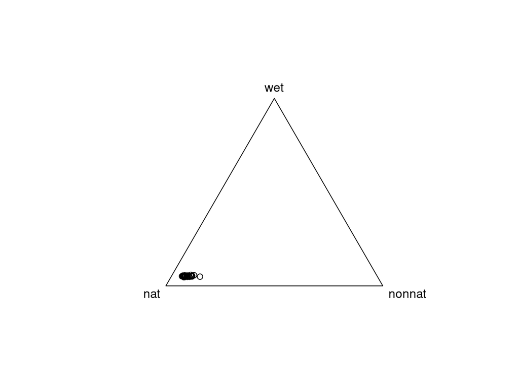

```r
year = '2020'
point20 <- chosenPoint %>%
  filter(between(
    date,
    as.Date(paste0(year, '-01-01')),
    as.Date(paste0(year, '-12-31')))) %>%
  drop_na(any_of(c("wet", "nat", "nonnat")))

point20X <- point20 %>% select(date) %>%
  st_drop_geometry() # to save memory
point20Y <- point20 %>% select(nat, nonnat, wet) %>%
  st_drop_geometry() %>%
  acomp() # force the probability triplet to sum to 1 making it compositional data
plot(point20Y)
```

Simple linear fit Y ~ X

```r
simpleLm20 <- lm(ilr(point20Y) ~ X, data = data.frame(X = point20X$date))
summary(simpleLm20)
```

```
## Response Y1 :
##
## Call:
## lm(formula = Y1 ~ X, data = data.frame(X = point20X$date))
##
## Residuals:
##      Min       1Q   Median       3Q      Max
## -0.27132 -0.13985 -0.04738  0.15179  0.50285
##
## Coefficients:
##               Estimate Std. Error t value Pr(>|t|)
## (Intercept) -6.5395792  6.5433221  -0.999    0.326
## X            0.0002589  0.0003559   0.728    0.473
##
## Residual standard error: 0.1939 on 27 degrees of freedom
## Multiple R-squared:  0.01923,    Adjusted R-squared:  -0.0171
## F-statistic: 0.5293 on 1 and 27 DF,  p-value: 0.4732
##
##
## Response Y2 :
##
## Call:
## lm(formula = Y2 ~ X, data = data.frame(X = point20X$date))
##
## Residuals:
##       Min        1Q    Median        3Q       Max
## -0.276728 -0.084251  0.006707  0.089996  0.164410
##
## Coefficients:
##               Estimate Std. Error t value Pr(>|t|)
## (Intercept) -3.088e+00  3.669e+00  -0.842    0.407
## X            9.854e-05  1.995e-04   0.494    0.625
##
## Residual standard error: 0.1087 on 27 degrees of freedom
## Multiple R-squared:  0.008954,   Adjusted R-squared:  -0.02775
## F-statistic: 0.2439 on 1 and 27 DF,  p-value: 0.6254
```

Model predictions, in composition space

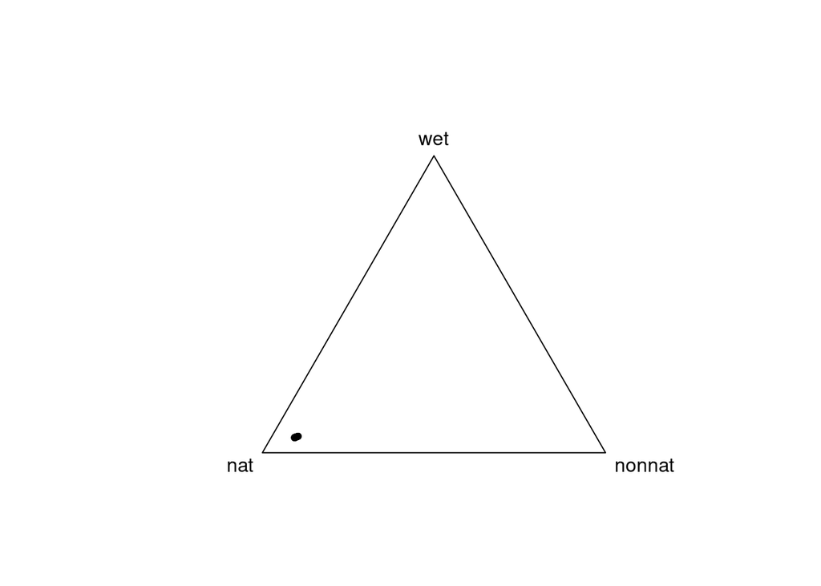

```r
plot(ilrInv(predict(simpleLm20)), pch=20)
```

Prediction residuals, in composition space

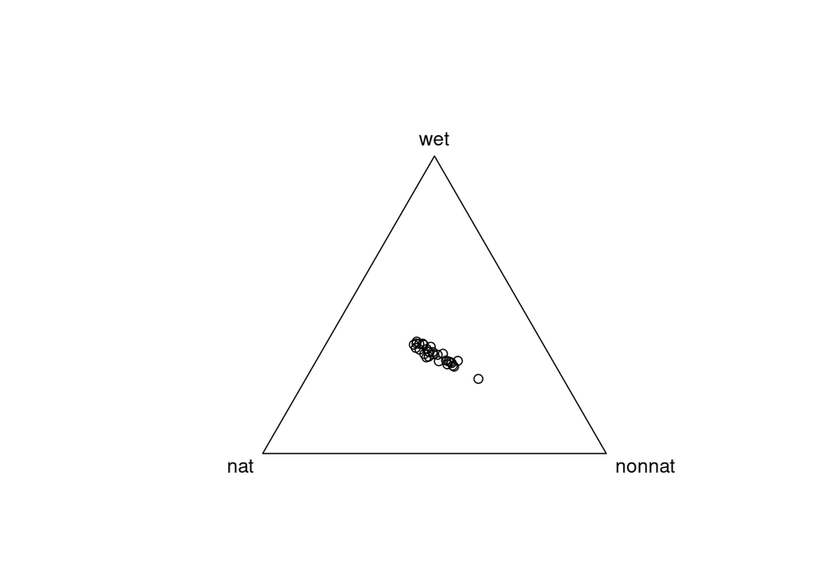

```r
plot(ilrInv(resid(simpleLm20)))
```

```r
# ellipses(mean(pointY), var(pointY))
# yPred <- ilrInv(predict(mylm, newdata=data.frame(X=pointX$date)))
# plot(yPred)
```

#### 3.3.1.2 Another year: 2022

Probabilities point cloud

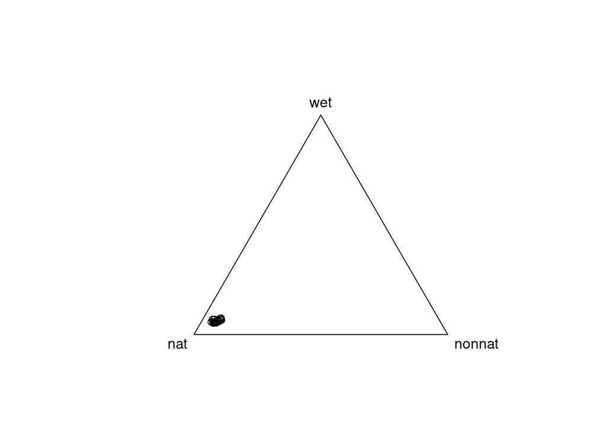

```r
year = '2022'
point22 <- chosenPoint %>%
  filter(between(
    date,
    as.Date(paste0(year, '-01-01')),
    as.Date(paste0(year, '-12-31')))) %>%
  drop_na(any_of(c("wet", "nat", "nonnat")))

point22X <- point22 %>% select(date) %>%
  st_drop_geometry()
point22Y <- point22 %>% select(nat, nonnat, wet) %>%
  st_drop_geometry() %>%
  acomp()
plot(point22Y)
```

Simple linear fit Y ~ X

```r
simpleLm22 <- lm(ilr(point22Y) ~ X, data = data.frame(X = point22X$date))
summary(simpleLm22)
```

```
## Response Y1 :
##
## Call:
## lm(formula = Y1 ~ X, data = data.frame(X = point22X$date))
##
## Residuals:
##      Min       1Q   Median       3Q      Max
## -0.33105 -0.07762  0.02973  0.08885  0.19140
##
## Coefficients:
##               Estimate Std. Error t value Pr(>|t|)
## (Intercept) -8.4846208  4.3596969  -1.946   0.0651 .
## X            0.0003419  0.0002280   1.500   0.1486
## ---
## Signif. codes:  0 '***' 0.001 '**' 0.01 '*' 0.05 '.' 0.1 ' ' 1
##
## Residual standard error: 0.1364 on 21 degrees of freedom
## Multiple R-squared:  0.09674,    Adjusted R-squared:  0.05373
## F-statistic: 2.249 on 1 and 21 DF,  p-value: 0.1486
##
##
## Response Y2 :
##
## Call:
## lm(formula = Y2 ~ X, data = data.frame(X = point22X$date))
##
## Residuals:
##       Min        1Q    Median        3Q       Max
## -0.122417 -0.044502 -0.005704  0.009206  0.200668
##
## Coefficients:
##               Estimate Std. Error t value Pr(>|t|)
## (Intercept) -9.5534580  2.7256783  -3.505  0.00211 **
## X            0.0004434  0.0001425   3.111  0.00529 **
## ---
## Signif. codes:  0 '***' 0.001 '**' 0.01 '*' 0.05 '.' 0.1 ' ' 1
##
## Residual standard error: 0.08527 on 21 degrees of freedom
## Multiple R-squared:  0.3155, Adjusted R-squared:  0.2829
## F-statistic: 9.679 on 1 and 21 DF,  p-value: 0.005286
```

Model predictions

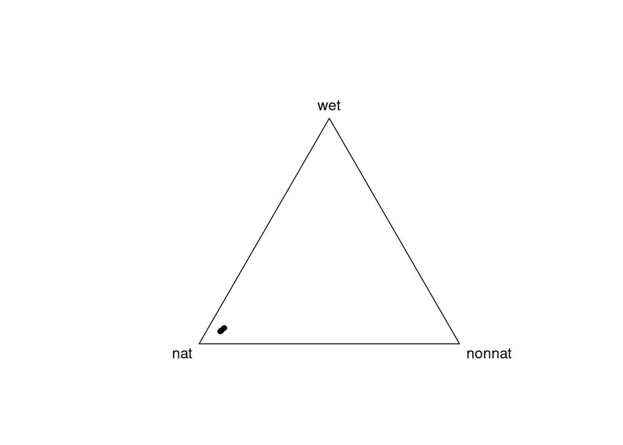

```r
plot(ilrInv(predict(simpleLm22)), pch=20)
```

Prediction residuals

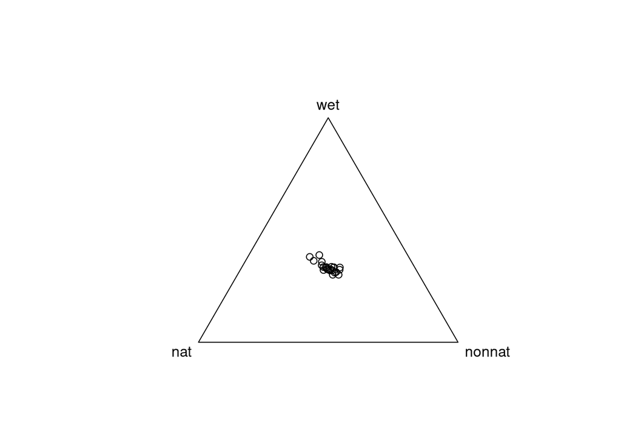

```r
plot(ilrInv(resid(simpleLm22)))
```

```r
# ellipses(mean(pointY), var(pointY))
# yPred <- ilrInv(predict(mylm, newdata=data.frame(X=pointX$date)))
# plot(yPred)
```

### 3.3.2 Harmonic fit

Borrowing from Nick Clinton’s YT tutorial on [Time Series Analysis in Earth Engine](https://www.youtube.com/watch?v=xQGNAYL7z80), construct a harmonic model.

#### 3.3.2.1 Year 2022

Harmonic fit Y ~ X + cos(2piX) + sin(2piX)

See pg. 13 of UsingCompositions.pdf for a demonstration on how to build a linear model where the response variable is compositional data, and predictor variable/s is/are real data (which is the case here).

```r
xc <- cos(2*pi*point22$timeMillis) # cosine
xs <- sin(2*pi*point22$timeMillis) # sine
harmLm22 <- lm(
  ilr(point22Y) ~ X + XC + XS,
  data = data.frame(X = point22X$date, XC = xc, XS = xs))
summary(harmLm22)
```

```
## Response Y1 :
##
## Call:
## lm(formula = Y1 ~ X + XC + XS, data = data.frame(X = point22X$date,
##     XC = xc, XS = xs))
##
## Residuals:
##       Min        1Q    Median        3Q       Max
## -0.231729 -0.062829 -0.001677  0.053987  0.183658
##
## Coefficients:
##               Estimate Std. Error t value Pr(>|t|)
## (Intercept) -4.014e+05  2.276e+05  -1.764   0.0938 .
## X            3.504e-04  2.251e-04   1.557   0.1360
## XC           4.014e+05  2.276e+05   1.764   0.0938 .
## XS          -2.403e+02  1.102e+02  -2.181   0.0420 *
## ---
## Signif. codes:  0 '***' 0.001 '**' 0.01 '*' 0.05 '.' 0.1 ' ' 1
##
## Residual standard error: 0.1276 on 19 degrees of freedom
## Multiple R-squared:  0.2845, Adjusted R-squared:  0.1715
## F-statistic: 2.518 on 3 and 19 DF,  p-value: 0.08889
##
##
## Response Y2 :
##
## Call:
## lm(formula = Y2 ~ X + XC + XS, data = data.frame(X = point22X$date,
##     XC = xc, XS = xs))
##
## Residuals:
##      Min       1Q   Median       3Q      Max
## -0.12620 -0.02988 -0.01678  0.02033  0.22404
##
## Coefficients:
##               Estimate Std. Error t value Pr(>|t|)
## (Intercept)  1.512e+05  1.535e+05   0.985  0.33696
## X            4.386e-04  1.518e-04   2.890  0.00938 **
## XC          -1.512e+05  1.535e+05  -0.985  0.33693
## XS           9.176e+01  7.431e+01   1.235  0.23194
## ---
## Signif. codes:  0 '***' 0.001 '**' 0.01 '*' 0.05 '.' 0.1 ' ' 1
##
## Residual standard error: 0.08606 on 19 degrees of freedom
## Multiple R-squared:  0.3692, Adjusted R-squared:  0.2696
## F-statistic: 3.707 on 3 and 19 DF,  p-value: 0.02968
```

Model predictions

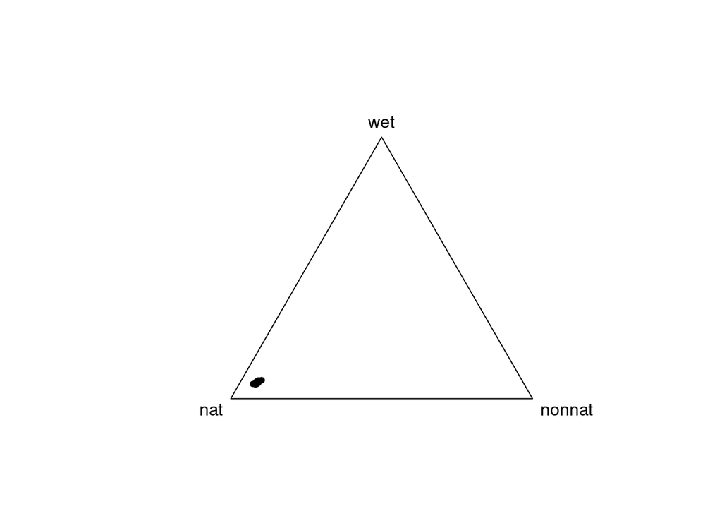

```r
plot(ilrInv(predict(harmLm22)), pch=20)
```

Prediction residuals

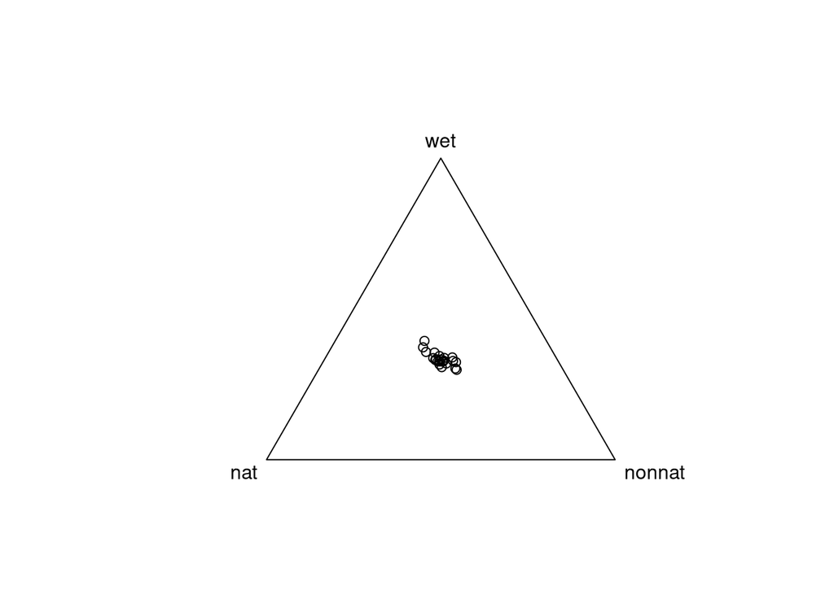

```r
plot(ilrInv(resid(harmLm22)))
```